```python
import pandas as pd
import plotly.express as px
import plotly.graph_objects as go
from plotly.subplots import make_subplots
import pypandoc
import matplotlib.pyplot as plt
import numpy as np
import statsmodels.api as sm
from sklearn import linear_model

import random

import matplotlib.pyplot as plt
from matplotlib import rcParams
import pandas as pd
import statsmodels.api as sm
import statsmodels.formula.api as smf
from statsmodels.nonparametric.smoothers_lowess import lowess
import numpy as np
import scipy.stats as stats

from sklearn.model_selection import train_test_split
from sklearn.metrics import confusion_matrix
from sklearn.metrics import accuracy_score
from sklearn.metrics import classification_report

from sklearn.linear_model import Ridge
from sklearn.model_selection import cross_val_score
from sklearn import linear_model

from sklearn.decomposition import PCA
from sklearn.model_selection import cross_val_score
from sklearn.preprocessing import StandardScaler
from sklearn.linear_model import LinearRegression
from sklearn.linear_model import LassoCV
from sklearn.linear_model import Lasso
from sklearn.linear_model import RidgeCV
```

# Exercise 9

```python
College = pd.read_csv('College.csv', index_col=0)
```

```python
College['Private_bool'] = College.Private.map(dict(No=0, Yes=1))
```

```python
predictors = list(College.columns)
```

```python
predictors.remove('Private')
predictors.remove('Apps')
```

```python
X = College[predictors]
X = sm.add_constant(X)
```

```python
y = College['Apps']
```

## 9a) Split the data set nto training and test set

```python
X_train, X_test, y_train, y_test = train_test_split(X, y, test_size=0.25, random_state=42)
```

## 9b) Fit linear model using least squares, report the test error

```python
model = sm.OLS(y_train,X_train).fit()
```

```python
model.summary()
```

OLS Regression Results

| Dep. Variable: | Apps | R-squared: | 0.943 |
| --- | --- | --- | --- |
| Model: | OLS | Adj. R-squared: | 0.942 |
| Method: | Least Squares | F-statistic: | 553.7 |
| Date: | Thu, 06 Aug 2020 | Prob (F-statistic): | 0.00 |
| Time: | 22:50:10 | Log-Likelihood: | -4809.1 |
| No. Observations: | 582 | AIC: | 9654. |
| Df Residuals: | 564 | BIC: | 9733. |
| Df Model: | 17 |  |  |
| Covariance Type: | nonrobust |  |  |

|  | coef | std err | t | P>\|t\| | [0.025 | 0.975] |
| --- | --- | --- | --- | --- | --- | --- |
| const | -259.5390 | 436.386 | -0.595 | 0.552 | -1116.679 | 597.601 |
| Accept | 1.7156 | 0.043 | 39.588 | 0.000 | 1.630 | 1.801 |
| Enroll | -1.2578 | 0.198 | -6.368 | 0.000 | -1.646 | -0.870 |
| Top10perc | 43.8312 | 5.805 | 7.551 | 0.000 | 32.429 | 55.233 |
| Top25perc | -10.0355 | 4.716 | -2.128 | 0.034 | -19.298 | -0.773 |
| F.Undergrad | 0.0626 | 0.035 | 1.775 | 0.076 | -0.007 | 0.132 |
| P.Undergrad | -0.0126 | 0.042 | -0.299 | 0.765 | -0.096 | 0.070 |
| Outstate | -0.0763 | 0.020 | -3.814 | 0.000 | -0.116 | -0.037 |
| Room.Board | 0.1739 | 0.052 | 3.369 | 0.001 | 0.072 | 0.275 |
| Books | 0.1170 | 0.261 | 0.448 | 0.654 | -0.396 | 0.629 |
| Personal | 0.0614 | 0.067 | 0.910 | 0.363 | -0.071 | 0.194 |
| PhD | -10.5702 | 5.103 | -2.071 | 0.039 | -20.593 | -0.547 |
| Terminal | -1.1547 | 5.484 | -0.211 | 0.833 | -11.926 | 9.617 |
| S.F.Ratio | 13.0572 | 13.433 | 0.972 | 0.331 | -13.327 | 39.441 |
| perc.alumni | 0.6542 | 4.412 | 0.148 | 0.882 | -8.012 | 9.320 |
| Expend | 0.0442 | 0.012 | 3.544 | 0.000 | 0.020 | 0.069 |
| Grad.Rate | 7.0856 | 3.021 | 2.345 | 0.019 | 1.151 | 13.020 |
| Private_bool | -626.4455 | 152.328 | -4.112 | 0.000 | -925.646 | -327.245 |

| Omnibus: | 366.204 | Durbin-Watson: | 1.777 |
| --- | --- | --- | --- |
| Prob(Omnibus): | 0.000 | Jarque-Bera (JB): | 9238.224 |
| Skew: | 2.316 | Prob(JB): | 0.00 |
| Kurtosis: | 21.961 | Cond. No. | 1.85e+05 |

Warnings:  
[1] Standard Errors assume that the covariance matrix of the errors is correctly specified.  
[2] The condition number is large, 1.85e+05. This might indicate that there are  
strong multicollinearity or other numerical problems.

```python
train_predictions = model.predict(X_train)
```

```python
correlation_matrix = np.corrcoef(y_train, train_predictions)
correlation_xy = correlation_matrix[0,1]
r_squared = correlation_xy**2
r_squared
```

```
0.9434660715063488
```

```python
test_predictions = model.predict(X_test)
```

```python
residual = y_test - test_predictions
```

```python
RSS = sum(residual ** 2)
```

```python
correlation_matrix = np.corrcoef(y_test, test_predictions)
correlation_xy = correlation_matrix[0,1]
r_squared = correlation_xy**2
r_squared
```

```
0.8621326638394663
```

Test Data shows a r^2 value of 0.86 using the linear model

## 9 c) Fit ridge regression on training set with lambda chosen by cross validation

```python
reg = linear_model.RidgeCV(alphas=np.logspace(-6, 6, 13),
                          normalize=True,
                          cv=5)
ridge_model = reg.fit(X_train,y_train)
ridge_model.alpha_
```

```
0.001
```

```python
lamda_cv = ridge_model.alpha_
```

```python
clf = Ridge(alpha=lamda_cv)
ridge_model = clf.fit(X_test,y_test)
train_predictions = ridge_model.predict(X_train)
test_predictions = ridge_model.predict(X_test)
```

```python
correlation_matrix = np.corrcoef(y_test, test_predictions)
correlation_xy = correlation_matrix[0,1]
r_squared = correlation_xy**2
r_squared
```

```
0.9225522692371647
```

From cross-validation, lamda was chosen to be 0.001. The r^2 value is calculated to be 0.923

## 9 d) Fit a lasso model on training set using cross-validation, report test error long with numer of non-zero coefficient estimates

```python
from sklearn.linear_model import LassoCV
from sklearn.linear_model import Lasso
```

```python
reg = LassoCV(alphas=np.logspace(-6, 6, 13),
                          normalize=True,
                          cv=5)
lasso_model = reg.fit(X_train,y_train)
lasso_model.alpha_
```

```
1e-06
```

```python
lasso_lamda_cv = lasso_model.alpha_
```

```python
clf = Lasso(alpha=lasso_lamda_cv)
lasso_model = clf.fit(X_test,y_test)
train_predictions = lasso_model.predict(X_train)
test_predictions = lasso_model.predict(X_test)
```

```python
correlation_matrix = np.corrcoef(y_test, test_predictions)
correlation_xy = correlation_matrix[0,1]
r_squared = correlation_xy**2
r_squared
```

```
0.9225522692379722
```

```python
lasso_model.get_params
```

```
<bound method BaseEstimator.get_params of Lasso(alpha=1e-06, copy_X=True, fit_intercept=True, max_iter=1000,
   normalize=False, positive=False, precompute=False, random_state=None,
   selection='cyclic', tol=0.0001, warm_start=False)>
```

```python
lasso_model.coef_
```

```
array([ 0.00000000e+00,  1.16205126e+00, -3.55962031e-02,  5.75795982e+01,
       -2.56627247e+01,  5.39548980e-02,  9.99588231e-02, -1.01936469e-01,
        3.39909832e-02, -2.26717458e-01, -1.92898110e-01, -6.66380237e-01,
       -6.90346690e+00,  2.47205069e+01, -1.90858616e+01,  2.20288530e-01,
        1.25551815e+01, -1.77157040e+02])
```

```python
X_train.columns
```

```
Index(['const', 'Accept', 'Enroll', 'Top10perc', 'Top25perc', 'F.Undergrad',
       'P.Undergrad', 'Outstate', 'Room.Board', 'Books', 'Personal', 'PhD',
       'Terminal', 'S.F.Ratio', 'perc.alumni', 'Expend', 'Grad.Rate',
       'Private_bool'],
      dtype='object')
```

From cross-validation, lamda was chosen to be 0.000001. The r^2 value is calculated to be 0.923. All predictors returned non-zero coefficient estimates.

## 9 e) Fit PCR model, with M chosen by cross validation

```python
pca = PCA(n_components=10)
```

```python
scaler = StandardScaler()
scaler.fit(X_train)
```

```
StandardScaler(copy=True, with_mean=True, with_std=True)
```

```python
scaler.mean_
```

```
array([1.00000000e+00, 1.98259794e+03, 7.43458763e+02, 2.72164948e+01,
       5.56718213e+01, 3.51138144e+03, 8.10893471e+02, 1.04643179e+04,
       4.35779038e+03, 5.44378007e+02, 1.32171821e+03, 7.25051546e+01,
       7.95446735e+01, 1.40685567e+01, 2.24415808e+01, 9.68663230e+03,
       6.53247423e+01, 7.35395189e-01])
```

```python
X_train_scaled = scaler.transform(X_train)
```

```python
pca.fit(X_train_scaled)
```

```
PCA(copy=True, iterated_power='auto', n_components=10, random_state=None,
  svd_solver='auto', tol=0.0, whiten=False)
```

```python
pca.explained_variance_ratio_
```

```
array([0.31170744, 0.25623823, 0.07265376, 0.05816785, 0.05513432,
       0.04830441, 0.03883994, 0.03398317, 0.02942634, 0.02512966])
```

```python
X_train_PC = pca.fit_transform(X_train_scaled)
```

```python
regr = LinearRegression()
```

```python
n = len(X_train_PC)
```

```python
r2_values = []
```

```python
# Null model (just intercept, no principal components in regression)
score = cross_val_score(regr, np.ones((n,1)), y_train, cv=5,scoring='r2').mean()
r2_values.append(score)
```

```python
for i in np.arange(1,11):
    score = cross_val_score(regr, X_train_PC[:,:i], y_train, cv=5,scoring='r2').mean()
    r2_values.append(score)
```

```
(-0.2, 10.2)
```

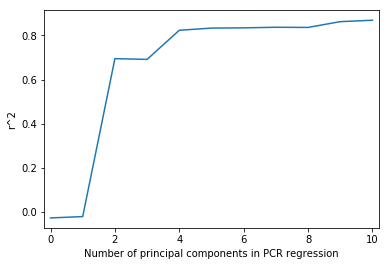

```python
plt.plot(np.arange(0, 11), np.array(r2_values), '-')
plt.xlabel('Number of principal components in PCR regression')
plt.ylabel('r^2')
plt.xlim((-0.2, 10.2))
```

4 Principal Components will be used

```python
X_test_scaled = scaler.transform(X_test)
```

```python
X_test_PC = pca.fit_transform(X_test_scaled)
```

```python
reg = LinearRegression().fit(X_train_PC[:,:4],y_train)
```

```python
train_predictions = reg.predict(X_train_PC[:,:4])
test_predictions = reg.predict(X_test_PC[:,:4])
```

```python
correlation_matrix = np.corrcoef(y_train, train_predictions)
correlation_xy = correlation_matrix[0,1]
r_squared = correlation_xy**2
r_squared
```

```
0.830752768709338
```

```python
correlation_matrix = np.corrcoef(y_test, test_predictions)
correlation_xy = correlation_matrix[0,1]
r_squared = correlation_xy**2
r_squared
```

```
0.5676179429695212
```

The test r^2 value was found to be 0.567, which is significantly lower than the training r^2 value of 0.83. This shows the model is significantly overfitting, even with cross-validation.

## 9 f) Fit a PLS model, with M chosen by cross validation. Report test error and value of M

```python
from sklearn.cross_decomposition import PLSRegression
```

```python
scaler = StandardScaler()
scaler.fit(X_train)
```

```
StandardScaler(copy=True, with_mean=True, with_std=True)
```

```python
X_train_scaled = scaler.transform(X_train)
X_test_scaled = scaler.transform(X_test)
```

```python
pls = PLSRegression(n_components=10)
```

```python
r2_values = []
```

```python
regr = LinearRegression()
```

```python
score = cross_val_score(regr, np.ones((n,1)), y_train, cv=5,scoring='r2').mean()
r2_values.append(score)
```

```python
for i in np.arange(1,11):
    pls = PLSRegression(n_components=i)
    score = cross_val_score(pls, X_train_scaled, y_train, cv=5,scoring='r2').mean()
    r2_values.append(score)
```

```python
r2_values
```

```
[-0.02837937435279092,
 0.7572409251764095,
 0.8581002977826998,
 0.8716642052268335,
 0.8877152401962369,
 0.90178365744157,
 0.9131085965117511,
 0.9171013989339997,
 0.9188349927648206,
 0.9194506262908838,
 0.920130427739851]
```

```
(-0.2, 10.2)
```

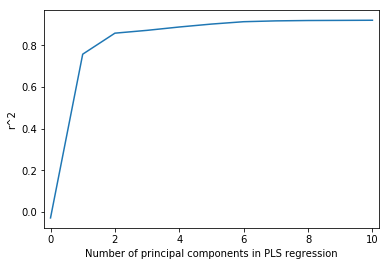

```python
plt.plot(np.arange(0, 11), np.array(r2_values), '-')
plt.xlabel('Number of principal components in PLS regression')
plt.ylabel('r^2')
plt.xlim((-0.2, 10.2))
```

6 components will be used

```python
pls = PLSRegression(n_components=6)
```

```python
pls
```

```
PLSRegression(copy=True, max_iter=500, n_components=6, scale=True, tol=1e-06)
```

```python
reg = pls.fit(X_train_scaled,y_train)
```

```python
train_predictions = reg.predict(X_train_scaled)
test_predictions = reg.predict(X_test_scaled)
```

```python
correlation_matrix = np.corrcoef(y_train, np.array(pd.DataFrame(train_predictions)[0]))
correlation_xy = correlation_matrix[0,1]
r_squared = correlation_xy**2
r_squared
```

```
0.9400601119499734
```

```python
correlation_matrix = np.corrcoef(y_test, np.array(pd.DataFrame(test_predictions)[0]))
correlation_xy = correlation_matrix[0,1]
r_squared = correlation_xy**2
r_squared
```

```
0.8661476357569482
```

The test r^2 value was found to be 0.866 for a PLS model with 6 components. This test error was significantly lower than the PCR model.

## 9 g) Comment on results

All of the models except the PCR model showed an r^2 value around 90%. The ridge regression and lasso models showed the best results.

# Exercise 11)

## 11 a) Try out some regression methods on Boston data set

```python
Boston = pd.read_csv("Boston.csv", index_col=0)
Boston_predictors = list(Boston.columns)
Boston_predictors.remove('crim')
```

```python
Boston_predictors
```

```
['zn',
 'indus',
 'chas',
 'nox',
 'rm',
 'age',
 'dis',
 'rad',
 'tax',
 'ptratio',
 'black',
 'lstat',
 'medv']
```

```python
Boston.head()
```

|  | crim | zn | indus | chas | nox | rm | age | dis | rad | tax | ptratio | black | lstat | medv |
| --- | --- | --- | --- | --- | --- | --- | --- | --- | --- | --- | --- | --- | --- | --- |
| 1 | 0.00632 | 18.0 | 2.31 | 0 | 0.538 | 6.575 | 65.2 | 4.0900 | 1 | 296 | 15.3 | 396.90 | 4.98 | 24.0 |
| 2 | 0.02731 | 0.0 | 7.07 | 0 | 0.469 | 6.421 | 78.9 | 4.9671 | 2 | 242 | 17.8 | 396.90 | 9.14 | 21.6 |
| 3 | 0.02729 | 0.0 | 7.07 | 0 | 0.469 | 7.185 | 61.1 | 4.9671 | 2 | 242 | 17.8 | 392.83 | 4.03 | 34.7 |
| 4 | 0.03237 | 0.0 | 2.18 | 0 | 0.458 | 6.998 | 45.8 | 6.0622 | 3 | 222 | 18.7 | 394.63 | 2.94 | 33.4 |
| 5 | 0.06905 | 0.0 | 2.18 | 0 | 0.458 | 7.147 | 54.2 | 6.0622 | 3 | 222 | 18.7 | 396.90 | 5.33 | 36.2 |

```python
X = Boston[Boston_predictors]
# X = sm.add_constant(X)
```

```python
y = Boston['crim']
```

```python
X_train, X_test, y_train, y_test = train_test_split(X, y, test_size=0.25, random_state=42)
```

```python
def fit_linear_reg(X,Y):
    #Fit linear regression model and return RSS and R squared values
    model_k = LinearRegression(fit_intercept = True)
    model_k.fit(X,Y)
    RSS = mean_squared_error(Y,model_k.predict(X)) * len(Y)
    R_squared = model_k.score(X,Y)
    return RSS, R_squared
```

```python
# Loop over all number of features possible in X
for i in np.arange(1,len(X.columns)+1):
    # loop over all possible combinations of parameters
    for combo in itertools.combinations(X.columns,i):
        tmp_result = fit_linear_reg(X_train[list(combo)],y_train)
        RSS_list.append(tmp_result[0])                  #Append lists
        R_squared_list.append(tmp_result[1])
        feature_list.append(combo)
        numb_features.append(len(combo))
```

```python
#Store in DataFrame
df = pd.DataFrame({'numb_features': numb_features,'RSS': RSS_list, 'R_squared':R_squared_list,'features':feature_list})
```

```python
df.head()
```

|  | numb_features | RSS | R_squared | features |
| --- | --- | --- | --- | --- |
| 0 | 1 | 25033.254854 | 0.041908 | (zn,) |
| 1 | 1 | 21970.667116 | 0.159122 | (indus,) |
| 2 | 1 | 26076.717054 | 0.001972 | (chas,) |
| 3 | 1 | 21999.034640 | 0.158036 | (nox,) |
| 4 | 1 | 24964.240903 | 0.044549 | (rm,) |

```python
# Find best subsets for each number of features
df_min = df[df.groupby('numb_features')['RSS'].transform(min) == df['RSS']]
df_max = df[df.groupby('numb_features')['R_squared'].transform(max) == df['R_squared']]
display(df_min.head(3))
display(df_max.head(3))
```

|  | numb_features | RSS | R_squared | features |
| --- | --- | --- | --- | --- |
| 7 | 1 | 15916.773894 | 0.390821 | (rad,) |
| 80 | 2 | 15293.384591 | 0.414680 | (rad, medv) |
| 346 | 3 | 15153.253010 | 0.420043 | (dis, rad, medv) |

|  | numb_features | RSS | R_squared | features |
| --- | --- | --- | --- | --- |
| 7 | 1 | 15916.773894 | 0.390821 | (rad,) |
| 80 | 2 | 15293.384591 | 0.414680 | (rad, medv) |
| 346 | 3 | 15153.253010 | 0.420043 | (dis, rad, medv) |

```python
df_min
```

|  | numb_features | RSS | R_squared | features |
| --- | --- | --- | --- | --- |
| 7 | 1 | 15916.773894 | 0.390821 | (rad,) |
| 80 | 2 | 15293.384591 | 0.414680 | (rad, medv) |
| 346 | 3 | 15153.253010 | 0.420043 | (dis, rad, medv) |
| 566 | 4 | 14911.306081 | 0.429303 | (zn, dis, rad, medv) |
| 1430 | 5 | 14777.585766 | 0.434421 | (zn, nox, dis, rad, medv) |
| 3016 | 6 | 14661.328163 | 0.438870 | (zn, nox, dis, rad, ptratio, medv) |
| 4850 | 7 | 14630.711902 | 0.440042 | (zn, nox, rm, dis, rad, ptratio, medv) |
| 6526 | 8 | 14607.347465 | 0.440936 | (zn, nox, rm, dis, rad, ptratio, lstat, medv) |
| 7471 | 9 | 14586.951759 | 0.441717 | (zn, chas, nox, rm, dis, rad, ptratio, lstat, ... |
| 8001 | 10 | 14572.753845 | 0.442260 | (zn, chas, nox, rm, dis, rad, tax, ptratio, ls... |
| 8156 | 11 | 14568.210196 | 0.442434 | (zn, chas, nox, rm, age, dis, rad, tax, ptrati... |
| 8179 | 12 | 14566.375370 | 0.442504 | (zn, indus, chas, nox, rm, age, dis, rad, tax,... |
| 8190 | 13 | 14566.156103 | 0.442513 | (zn, indus, chas, nox, rm, age, dis, rad, tax,... |

```python
df.iloc[[df['R_squared'].idxmax()]]
```

|  | numb_features | RSS | R_squared | features |
| --- | --- | --- | --- | --- |
| 8190 | 13 | 14566.156103 | 0.442513 | (zn, indus, chas, nox, rm, age, dis, rad, tax,... |

```python
df.iloc[[df['RSS'].idxmin()]]
```

|  | numb_features | RSS | R_squared | features |
| --- | --- | --- | --- | --- |
| 8190 | 13 | 14566.156103 | 0.442513 | (zn, indus, chas, nox, rm, age, dis, rad, tax,... |

The max R^2 value is calculated with 13 features, with a r^2 value of 0.44.

### Lasso Method

```python
scaler = StandardScaler()
scaler.fit(X_train)
```

```
StandardScaler(copy=True, with_mean=True, with_std=True)
```

```python
X_train_scaled = scaler.transform(X_train)
X_test_scaled = scaler.transform(X_test)
```

```python
reg = LassoCV(alphas=np.logspace(-6, 6, 13),
                          cv=5)
lasso_model = reg.fit(X_train_scaled,y_train)
lasso_model.alpha_
```

```
0.1
```

```python
lasso_lamda_cv = lasso_model.alpha_
```

```python
clf = Lasso(alpha=lasso_lamda_cv)
lasso_model = clf.fit(X_train_scaled,y_train)
train_predictions = lasso_model.predict(X_train_scaled)
test_predictions = lasso_model.predict(X_test_scaled)
```

```python
correlation_matrix = np.corrcoef(y_test, test_predictions)
correlation_xy = correlation_matrix[0,1]
r_squared = correlation_xy**2
r_squared
```

```
0.4491938517831957
```

```python
lasso_model.get_params
```

```
<bound method BaseEstimator.get_params of Lasso(alpha=0.1, copy_X=True, fit_intercept=True, max_iter=1000,
   normalize=False, positive=False, precompute=False, random_state=None,
   selection='cyclic', tol=0.0001, warm_start=False)>
```

```python
lasso_model.coef_
```

```
array([ 0.64838589, -0.01460102, -0.20950913, -0.55299636,  0.12980148,
        0.        , -1.36610638,  4.47999919,  0.        , -0.34154601,
       -0.        ,  0.29998983, -1.45993363])
```

```python
X_train.columns
```

```
Index(['zn', 'indus', 'chas', 'nox', 'rm', 'age', 'dis', 'rad', 'tax',
       'ptratio', 'black', 'lstat', 'medv'],
      dtype='object')
```

The lasso model was created using cross validation on the training set to get a lamda value of 0.1. The Model then was run on the test set, with a calculated R^2 value of 0.45. 3 of the features coefficients were set to 0 (age, tax and black)

### Ridge Regression

```python
reg = linear_model.RidgeCV(alphas=np.logspace(-6, 6, 13),
                          normalize=True,
                          cv=5)
ridge_model = reg.fit(X_train,y_train)
ridge_model.alpha_
```

```
0.1
```

```python
lamda_cv = ridge_model.alpha_
```

```python
clf = Ridge(alpha=lamda_cv, normalize=True)
ridge_model = clf.fit(X_train_scaled,y_train)
train_predictions = ridge_model.predict(X_train)
test_predictions = ridge_model.predict(X_test)
```

```python
correlation_matrix = np.corrcoef(y_test, test_predictions)
correlation_xy = correlation_matrix[0,1]
r_squared = correlation_xy**2
r_squared
```

```
0.3878344853176898
```

```python
ridge_model.coef_
```

```
array([ 0.60112815, -0.28389894, -0.25287885, -0.55229301,  0.28356927,
        0.18877146, -1.27407228,  3.34118918,  0.95216337, -0.25362661,
       -0.15566845,  0.59666058, -1.28711772])
```

For the ridge model, from cross-validation, lamda was chosen to be 0.1. The r^2 value is calculated to be 0.387.

### PCR

```python
pca = PCA(n_components=13)
```

```python
pca.fit(X_train_scaled)
```

```
PCA(copy=True, iterated_power='auto', n_components=13, random_state=None,
  svd_solver='auto', tol=0.0, whiten=False)
```

```python
pca.explained_variance_ratio_
```

```
array([0.46615845, 0.1324862 , 0.094738  , 0.06937191, 0.06729794,
       0.05154546, 0.03135448, 0.02267416, 0.0182164 , 0.01653708,
       0.01384151, 0.01072723, 0.00505118])
```

```python
X_train_PC = pca.fit_transform(X_train_scaled)
```

```python
regr = LinearRegression()
```

```python
n = len(X_train_PC)
```

```python
r2_values = []
```

```python
# Null model (just intercept, no principal components in regression)
score = cross_val_score(regr, np.ones((n,1)), y_train, cv=5,scoring='r2').mean()
r2_values.append(score)
```

```python
for i in np.arange(1,11):
    score = cross_val_score(regr, X_train_PC[:,:i], y_train, cv=5,scoring='r2').mean()
    r2_values.append(score)
```

```
(-0.2, 10.2)
```

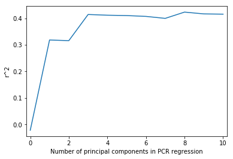

```python
plt.plot(np.arange(0, 11), np.array(r2_values), '-')
plt.xlabel('Number of principal components in PCR regression')
plt.ylabel('r^2')
plt.xlim((-0.2, 10.2))
```

8 Principal Components will be used

```python
X_test_scaled = scaler.transform(X_test)
```

```python
X_test_PC = pca.fit_transform(X_test_scaled)
```

```python
reg = LinearRegression().fit(X_train_PC[:,:8],y_train)
```

```python
train_predictions = reg.predict(X_train_PC[:,:8])
test_predictions = reg.predict(X_test_PC[:,:8])
```

```python
correlation_matrix = np.corrcoef(y_train, train_predictions)
correlation_xy = correlation_matrix[0,1]
r_squared = correlation_xy**2
r_squared
```

```
0.4081092776438006
```

```python
correlation_matrix = np.corrcoef(y_test, test_predictions)
correlation_xy = correlation_matrix[0,1]
r_squared = correlation_xy**2
r_squared
```

```
0.22572127269283443
```

The test r^2 value was found to be 0.226, which is significantly lower than the training r^2 value of 0.41. This shows the model is significantly overfitting, even with cross-validation.

## 9 b) Propose a model that will perform well on this data set.

The lasso model has the highest r^2 value so I would propose that model, although it's r^2 value is relatively low at 0.44.

## 9 c) Does chosen model include all features in data set?

No, the lasso model chosen removes three features by setting their coefficients to zero.